# Predicting Depression from Sociological Variables using Machine Learning

Data Science Senior Thesis

Author

Ali Slayie

Published

April 22, 2025

**Github Repo Link**

[Link to Repository](https://github.com/ali3el/alis-thesis.git)

# Introduction

Depression remains one of the most prevalent and complex issues in public health in the United States. While the condition affects people across all demographics, its distribution and severity are far from random. Research has consistently shown how social determinants such as migration status, sexual orientation, and gender identity can shape mental health outcomes. However, these sociological variables are often underexplored in predictive modeling, especially in ways that reflect their impacts through an intersectional lens.

This thesis frames mental health prediction not just as a question of individual outcomes, but as a data science challenge rooted in social complexity. By using the National Health Interview Survey (NHIS) from 2019 to 2023, I explore whether depression can be effectively predicted based on a range of demographic and social variables—particularly those tied to migration and LGBTQ+ (Lesbian, Gay, Bisexual, Transgender, Queer, and more) identity. Rather than treating these as fixed categories, this project examines the predictive power of these identities through rigorous modeling, subgroup balancing, and model interpretation techniques.

The objective of this project is not only to identify which variables are most predictive of depression but also to demonstrate how thoughtful data preparation, model evaluation, and interpretation can shed light on social disparities without compromising technical rigor. While the topic is socially meaningful, the thesis remains firmly situated in the data science domain, emphasizing methodological complexity, performance benchmarking, and scalable analysis pipelines.

## Research Questions and Objectives

This thesis is guided by the following core research questions:

1. To what extent can depression be predicted using sociologically meaningful variables from the NHIS dataset—particularly those related to migration and LGBTQ+ identity?
2. How do model performance and feature importance vary across four key subgroups: LGBTQ+ migrants, LGBTQ+ non-migrants, straight migrants, and straight non-migrants?
3. Which data preparation, subgroup balancing, and model tuning strategies yield the strongest predictive performance?
4. How can explainability techniques help interpret and contextualize model predictions in a socially responsible way?

The objective is to build a technically rigorous, interpretable, and generalizable predictive pipeline that demonstrates advanced data science capabilities, while ensuring that social context informs—rather than overshadows—the modeling process.

# Literature Review

Although depression has been widely studied across disciplines, most existing research focuses on documenting disparities or testing associations, rather than developing predictive models. This thesis contributes to a growing body of work that leverages machine learning to predict mental health outcomes, while incorporating sociologically meaningful variables such as race, gender identity, sexual orientation, and migration status. By emphasizing interpretability, this project bridges technical rigor with social awareness.

This work sits at the intersection of two under-connected literatures — sociological theory on structural inequality and algorithmic modeling in health research — and aims to address the limitations of both.

## Machine Learning for Mental Health Prediction

Recent years have seen increased use of machine learning (ML) in mental health research, including efforts to predict depression from electronic health records, online behavior, or self-report surveys. For example, Nickson et al. (2023) conducted a systematic review of ML-based approaches using electronic health records to predict depression, highlighting a wide range of models, including logistic regression, support vector machines, and ensemble methods, while also acknowledging the lack of subgroup-specific evaluation ([source](https://bmcmedinformdecismak.biomedcentral.com/articles/10.1186/s12911-023-02341-x)). Similarly, Lee and Ham (2022) reviewed recent applications of machine learning in early depression diagnosis and noted the dominance of black-box models that prioritize performance over interpretability ([source](https://www.ncbi.nlm.nih.gov/pmc/articles/PMC9441463/?utm_source=chatgpt.com)).

Even studies that aim to improve interpretability often focus on feature engineering or performance tuning, without accounting for identity-based variation in prediction quality. Furthermore, many predictive models operate as “black boxes,” offering high accuracy but limited insight into the mechanisms behind their predictions. This thesis builds on emerging work that employs interpretable models—such as decision trees—alongside model explanation techniques like SHAP values and partial dependence plots, in order to provide transparent, actionable insights. The approach incorporates repeated cross-validation, subgroup balancing, and structured data preparation—key components of a robust predictive modeling framework.

Few existing studies stratify model performance across intersectional identities, making it difficult to assess fairness or subgroup validity in mental health prediction. This project addresses that gap directly.

## Sociological Determinants of Depression

Extensive research has shown that LGBTQ+ individuals and migrants face elevated risks of depression, anxiety, and related mental health conditions. These disparities are shaped by chronic exposure to stress, discrimination, and systemic barriers to care. For example, LGB adults are significantly more likely to experience depression and suicidal ideation than their heterosexual peers ([source](https://www.ncbi.nlm.nih.gov/pmc/articles/PMC7876969/)). Migrants often face compounded stress from legal precarity, social isolation, and acculturative pressures, which can further increase risk. Structural inequalities — such as housing insecurity, lack of insurance, and regional disparities in care — also play a key role.

Medical comorbidities, often more prevalent in marginalized groups, further complicate the mental health landscape. Conditions such as hypertension ([source](https://www.ncbi.nlm.nih.gov/pmc/articles/PMC4077111/)), cholesterol imbalance ([source](https://www.ncbi.nlm.nih.gov/pmc/articles/PMC4215473/)), cardiovascular disease ([source](https://www.ncbi.nlm.nih.gov/pmc/articles/PMC10951381/)), chronic obstructive pulmonary disease (COPD) ([source](https://journal.copdfoundation.org/jcopdf/id/1482/From-Invisibility-to-Inclusion-A-Call-to-Action-to-Address-COPD-Disparities-in-the-Lesbian-Gay-Bisexual-Transgender-and-Queer-Community)), epilepsy ([source](https://healthlgbtq.org/resources-news/)), and inflammatory bowel disease (IBD) ([source](https://www.health.harvard.edu/blog/ibd-and-lgbtq-how-it-can-affect-sexual-health-202306282949)) have all been linked to increased risk of depression. These health conditions disproportionately affect LGBTQ+ individuals, adding biomedical complexity to social disadvantage.

While these patterns are well-established in the public health literature, they are rarely integrated into predictive frameworks that account for both medical and social risk factors.

## Bridging Disciplinary Gaps

Sociological literature frequently invokes theories of intersectionality and minority stress to explain disparities in mental health. However, much of this research remains qualitative or descriptive, and rarely incorporates large-scale datasets. On the other hand, many data science applications ignore identity-based variables or fail to contextualize their predictions within structural inequalities. This thesis seeks to bridge these gaps by combining interpretable modeling with identity- and condition-based features derived from five years of the National Health Interview Survey (NHIS).

The minority stress model ([Meyer, 2003](https://www.ncbi.nlm.nih.gov/pmc/articles/PMC2072932/)) has been instrumental in explaining elevated mental health risks among LGBTQ+ individuals, but such frameworks have not yet been operationalized through algorithmic modeling. Similarly, few studies explore how these dynamics interact with migration status in statistical models.

The inclusion of features like anxiety history, physical comorbidities, and demographic identity reflects an intentional blending of sociological theory with algorithmic modeling. By balancing the dataset across LGBTQ+ and migrant subgroups and applying explainability techniques, this project aims to build not only accurate but also socially conscious predictive tools.

Unlike most prior work, this thesis evaluates model fairness across four distinct subgroups (LGBTQ+ migrants, LGBTQ+ non-migrants, straight migrants, straight non-migrants), offering one of the first intersectional evaluations of depression prediction performance using interpretable machine learning.

# Data Source Overview and Cleaning

This project utilizes data from the [National Health Interview Survey (NHIS)](https://www.cdc.gov/nchs/nhis/index.html), a large-scale, nationally representative survey conducted by the U.S. Centers for Disease Control and Prevention (CDC). The dataset provides detailed information on the health, demographic, and socioeconomic characteristics of individuals in the United States. Data from multiple years (2019–2023) were consolidated into a single dataset, resulting in a robust sample of over 100,000 observations.

During the data cleaning process, consistent variable naming conventions were applied across all datasets to ensure uniformity. For example, variables such as *EDUC_A* and *MAXEDUC_A* were renamed to more descriptive labels like *education_level* and *max_education_level* to improve clarity. Missing columns were added where necessary, and missing values were handled using mode imputation for categorical variables (e.g., imputing the most common value for region) and median imputation for numeric variables (e.g., filling in missing age values with the median age).

Variable types were also standardized to align with the requirements of various modeling approaches. Binary variables such as *depression_ever* and *anxiety_ever* were encoded with levels “Yes” and “No,” while ordinal variables like *life_satisfaction* were mapped to ordered levels ranging from “Very dissatisfied” to “Very satisfied.” These steps ensured the dataset was fully prepared for feature construction and downstream modeling tasks.

Figure Figure 1 below shows the distribution of the final sample, stratified by the identity groups used throughout the project.

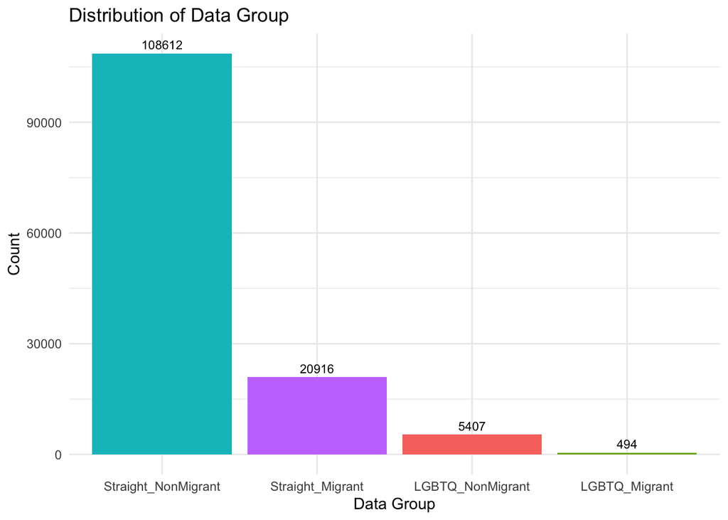

Figure 1: Distribution of Focus Group

## Target Variable

The target variable is self-reported depression, measured by the NHIS variable *DEPEV_A* (“Have you ever had depression?”). This binary variable serves as the outcome of interest for all classification models. Because this variable is binary, the modeling task is framed as a classification problem.

Figure Figure 2 below shows the distribution of self-reported depression responses in the dataset.

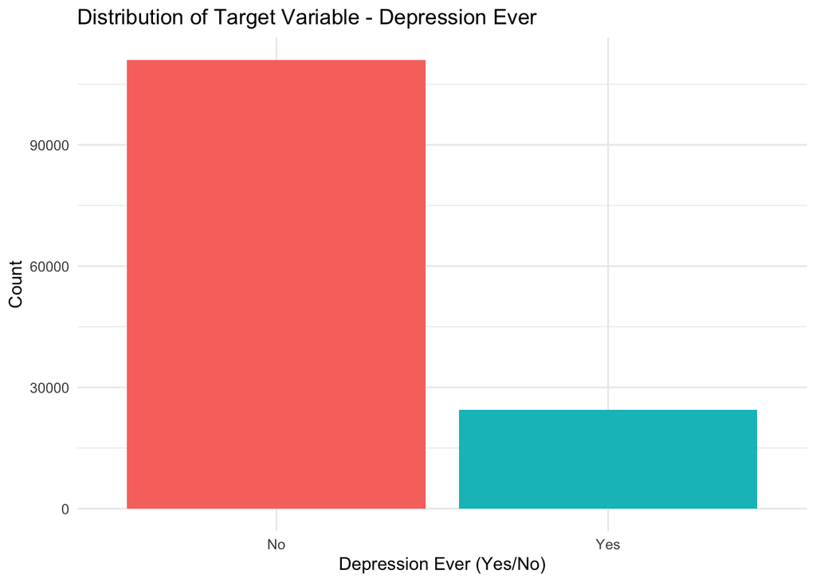

Figure 2: Distribution of Target Variable

## Key Predictors

To investigate the social and structural factors influencing depression, this project used an incremental modeling strategy, adding predictors step-by-step across four model types, allowing for a clear understanding of how different variable sets contribute to predictive performance. This structure also helped isolate the predictive contribution of group membership relative to other explanatory factors.

The variable sets used in each model were:

- **Model 1: Group Membership Only**  
  Included a single categorical variable representing identity group membership: LGBTQ+ migrant, LGBTQ+ non-migrant, straight migrant, and straight non-migrant. This baseline model assessed whether group membership alone was predictive of depression outcomes. An accompanying OLS model was also run on `PHSTAT_A` (self-rated health) to capture group differences in general health perception.
- **Model 2: Group Membership + Demographic Variables**  
  Added basic demographic features including:
  - Gender identity
  - Age
  - Race and ethnicity
  - Geographic region  
    These variables were selected to control for population-level variation and explore whether group-based disparities persisted after accounting for them.
- **Model 3: + Socioeconomic Status (SES) Variables**  
  Built on Model 2 by introducing variables reflecting socioeconomic conditions:
  - Education level
  - Insurance coverage
  - Marital status
  - Parental status  
    These indicators were intended to capture social positioning and access to resources; factors that often intersect with both identity and mental health outcomes.
- **Model 4: + Mental Health Care Access and Utilization**  
  The final model included variables related to structural access to care:
  - Frequency of medical visits
  - Access to a regular healthcare provider
  - Ability to afford care
  - Medication use  
    These predictors allowed for the evaluation of healthcare access as a potential pathway linking group membership to depression risk.

Across all models, the inclusion of predictors was informed by existing public health literature (see Literature Review) and the availability of consistently coded variables across the 2019–2023 NHIS files.

## Modeling Workflow Overview

To support experimentation and scalability, I constructed two modeling pipelines:

This two-track approach allowed for fast iteration and robust evaluation, while ensuring that all modeling decisions were transferable between the smaller and larger datasets.

# Methods

## Group Construction & Dataset Balancing

To investigate how mental health outcomes differ across social identities, I constructed a categorical group variable that combines two binary indicators: LGBTQ+ identity and migration status. This resulted in four mutually exclusive groups:

1. LGBTQ+ migrants
2. LGBTQ+ non-migrants
3. Straight migrants
4. Straight non-migrants

Initial exploration of the NHIS dataset revealed substantial class imbalance—both in the distribution of the target variable (depression) and in the sizes of these identity groups. To mitigate bias and ensure fair representation across all four subgroups, I created a **balanced analytical dataset of approximately 40,000 observations**, with roughly **10,000 observations per group**.

This dataset was constructed using a combination of **increasing the number of samples in underrepresented groups (upsampling)** and **downsampling overrepresented ones**. By maintaining balance across the four identity-based groups, this approach allowed for a clearer comparison of model performance and subgroup disparities without the confounding effects of unequal sample sizes.

All modeling in this thesis was conducted on this balanced dataset to align with the project’s emphasis on **equity-aware modeling**, interpretability, and methodological consistency across experiments.

## Data Splitting & Resampling Strategy

All modeling was conducted on a balanced dataset of approximately 40,000 observations, with equal representation across the four identity-based subgroups. Two resampling setups were used throughout the project to train and evaluate the models.

- **Initial modeling (local machine)** used **4-fold cross-validation with 3 repeats**, allowing for fast iteration and exploratory analysis of different variable sets and model types resulting in 12 total resamples per model.
- **Final modeling (Quest high-performance cluster)** used a more rigorous **10-fold cross-validation with 5 repeats**, resulting in 50 total resamples per model. This setup provided more stable performance estimates and was used for final evaluations and comparisons.

In both setups, **stratified resampling** was used based on the binary depression indicator to preserve class proportions within each fold. This ensured consistent performance measurement and reduced bias due to class imbalance.

The use of two-tiered cross-validation allowed the project to balance exploratory modeling with rigorous evaluation—without compromising reproducibility.

## Model Types

To explore a range of predictive strategies, I implemented five classification algorithms using a unified modeling framework in R (*tidymodels*). These models were chosen to reflect varying levels of complexity, flexibility, and interpretability:

- **Logistic Regression**  
  A linear model commonly used for binary classification. It provides coefficients that are easy to interpret and serves as a strong baseline.
- **Decision Tree**  
  A rule-based model that splits data into segments based on feature thresholds. It offers transparent, human-readable logic for prediction.
- **K-Nearest Neighbors (KNN)**  
  A non-parametric model that assigns classes based on the majority label among the nearest data points. It is useful for capturing local structure in the data.
- **Naive Bayes**  
  A probabilistic model that applies Bayes’ Theorem under the assumption of feature independence. It performs surprisingly well in many high-dimensional settings.
- **RuleFit**  
  A hybrid model that extracts rules from tree ensembles and combines them with linear terms. It balances performance with interpretability by using learned rules as features in a sparse linear model.

These models were trained and evaluated using the same cross-validation strategy on the balanced 40k dataset. The goal was to assess how different learning algorithms perform in predicting depression outcomes using sociologically-informed variables.

## Preprocessing Pipelines - Feature Engineering

To systematically evaluate how different sets of predictors influence model performance, I developed four core preprocessing pipelines (Model Types 1–4), each representing a different level of variable complexity. Each feature set was defined using a structured preprocessing workflow in R, and each had two versions: one for **tree-based models** and one for **non-tree (parametric) models**.

In addition to these four structured pipelines, I also created a separate **Kitchen Sink** feature set that included all available predictors, serving as a maximal model for benchmarking purposes.

### Predictor Sets by Model Type

- **Model Type 1 (M1): Group-Only Model**  
  Included only the categorical variable for identity group membership (LGBTQ+ migrant, LGBTQ+ non-migrant, straight migrant, straight non-migrant).
- **Model Type 2 (M2): + Demographics**  
  Added basic demographic variables such as age, gender identity, race/ethnicity, and geographic region.
- **Model Type 3 (M3): + Socioeconomic Status (SES)**  
  Built on M2 by including socioeconomic variables such as education level, insurance coverage, marital status, and parental status.
- **Model Type 4 (M4): + Healthcare Access and Behavior**  
  Included variables related to healthcare usage and access (e.g., number of doctor visits, therapy history, housing status, physical health rating).
- **Kitchen Sink**  
  A separate feature set that included all available predictors in the dataset, spanning identity, demographic, socioeconomic, behavioral, and healthcare-related variables.

### Tree-Based vs. Non-Tree-Based Feature Sets

Each model type was implemented using **two parallel feature sets** depending on the algorithm class:

- **Non-Tree-Based Models** (e.g., Logistic Regression, Naive Bayes, KNN):
  - Dummy encoding for categorical variables
  - Normalization of numeric predictors
  - Mode imputation for categorical variables; median imputation for numeric
  - Removal of near-zero variance predictors
- **Tree-Based Models** (e.g., Decision Tree, RuleFit):
  - One-hot encoding for categorical variables
  - Skipped normalization (not needed for decision-based splits)
  - Same imputation and near-zero variance removal steps as above

This setup ensured that models were trained on appropriately preprocessed data based on their algorithmic assumptions, while keeping predictor sets consistent across model types.

All preprocessing workflows were executed using standard tools in R and saved for reproducibility.

## Resampling Technique

To evaluate the generalizability of all models and reduce the risk of overfitting, I used **V-fold cross-validation with repeated resampling**. This method involves partitioning the dataset into *V* equal-sized folds, training the model on *V–1* folds, and validating it on the remaining fold. The process is repeated so that each fold serves as a validation set multiple times, and the results are averaged to estimate model performance.

Two resampling configurations were used:

- **Local experiments (exploratory phase):**  
  Used **4-fold cross-validation with 3 repeats**, resulting in **12 total resamples per model**. This setup allowed for quick prototyping across different feature sets and models on a local machine.
- **Final modeling (Quest high-performance cluster):**  
  Used **10-fold cross-validation with 5 repeats**, resulting in **50 resamples per model**. This more rigorous configuration provided stable and generalizable performance estimates for final evaluation.

In both cases, **stratified resampling** was used based on the binary depression outcome to ensure consistent class proportions across all folds.

This two-tiered strategy balanced efficiency and rigor: fast iteration locally, followed by deeper evaluation at scale.

## Performance Metrics

The primary performance metric for model comparison was the **F1 Score**, which balances precision and recall. This metric was selected due to the class imbalance in the target variable and the importance of not over-prioritizing one class over the other.

Secondary metrics included:

- **Accuracy**: the proportion of correctly classified observations
- **Area Under the ROC Curve (AUC)**: measures the ability of the model to distinguish between the two classes across all classification thresholds, reflecting the model’s ability to rank positive cases higher than negative ones
- **Precision and Recall**: reported individually to further interpret F1 dynamics

All metrics were computed and averaged across resampling iterations to ensure stable and unbiased comparisons across model types.

# Results

## Modeling Overview

To support both experimentation and scalability, models were run on two platforms: - A **local pipeline** using 4-fold cross-validation with 3 repeats (12 resamples total) - A **Quest high-performance pipeline** using 10-fold cross-validation with 5 repeats (50 resamples total)

## Model and Feature Sets Comparison

The best-performing configuration was a **Decision Tree trained on the full feature set (Kitchen Sink)**, trained and evaluated on the **Quest** high-performance computing cluster. This model achieved:

- **F1 Score:** ≈ 0.901
- **Accuracy:** ≈ 0.90
- **ROC AUC:** ≈ 0.95
- **Precision:** 0.91
- **Recall:** 0.93

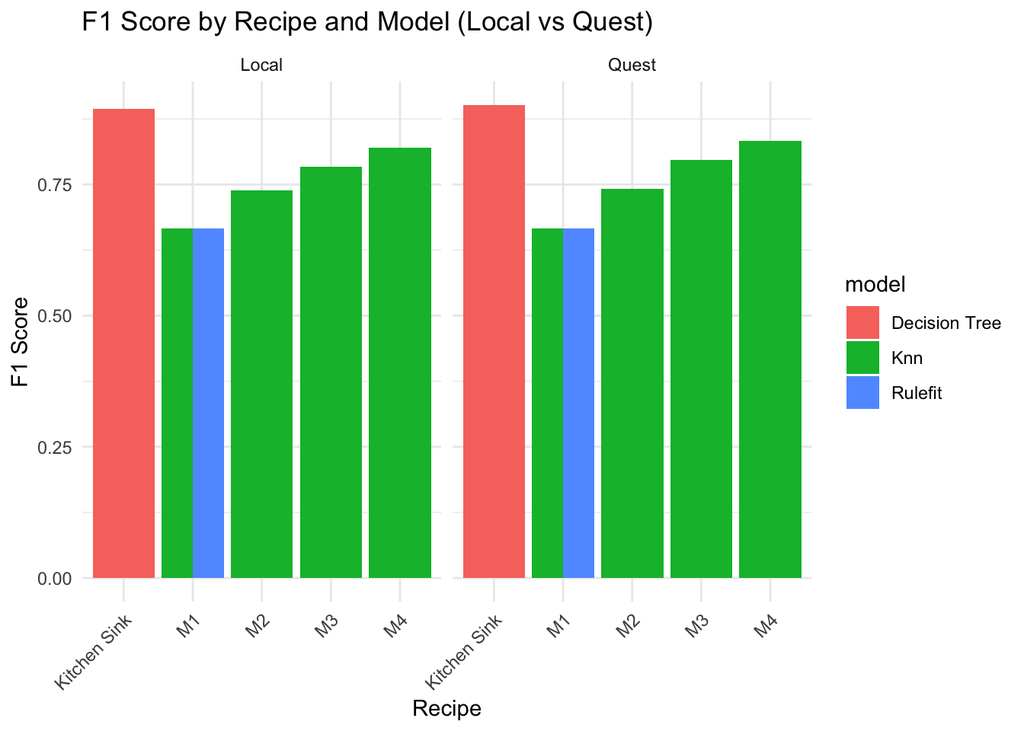

Figure 3: F1 Scores by Model and Feature Set (Grouped by Platform)

## Accuracy and ROC AUC Trends

While F1 score served as the primary evaluation metric, examining **accuracy** and **ROC AUC** provides a more complete picture of model performance.

As shown in **Figure 4**, accuracy trends closely mirrored the F1 score rankings. The **Decision Tree + Kitchen Sink** model (Quest) not only achieved the highest F1 score, but also led in accuracy at approximately **90%**, reinforcing its strong predictive capacity across multiple metrics. Similarly, **KNN models paired with M3 and M4** performed well on both platforms.

ROC AUC trends, shown in **Figure 5**, further contextualize these findings. While most high-F1 models also had high AUC scores (above 0.85), some models—such as **KNN + M2 (Quest)**—achieved strong AUC values despite more modest F1 scores. This indicates good class separation overall, but potentially uneven performance on one class (e.g., lower precision or recall).

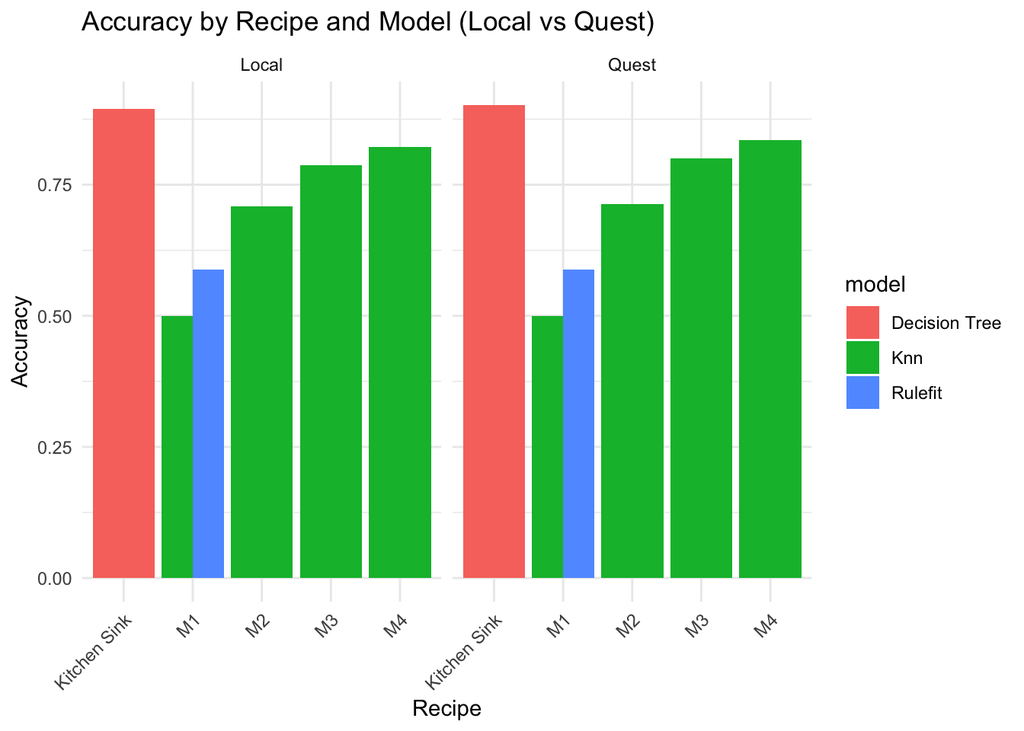

Figure 4: Accuracy by Model and Feature Set (Grouped by Platform)

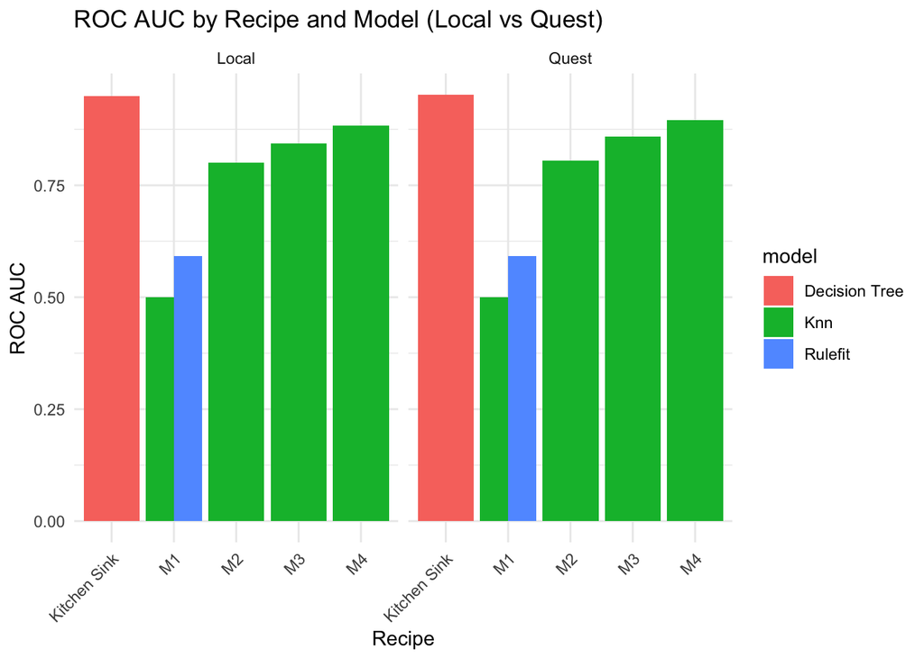

Figure 5: ROC AUC by Model and Feature Set (Grouped by Platform)

## Summary of Best-Performing Models

Table 1: Accuracy by Model and Feature Set (Grouped by Platform)

| model | accuracy | precision | recall | f_meas | roc_auc | std_err_f_meas | attempt | platform | recipe |
| --- | --- | --- | --- | --- | --- | --- | --- | --- | --- |
| Decision Tree | 0.894 | 0.896 | 0.927 | 0.894 | 0.950 | 0.001 | 1 | Local | Kitchen Sink |
| KNN | 0.708 | 0.679 | 0.846 | 0.739 | 0.800 | 0.001 | 2 | Local | M2 |
| KNN | 0.787 | 0.797 | 0.772 | 0.784 | 0.843 | 0.002 | 3 | Local | M3 |
| KNN | 0.500 | 0.500 | 1.000 | 0.667 | 0.500 | 0.000 | 4 | Local | M1 |
| RuleFit | 0.588 | 0.604 | 1.000 | 0.667 | 0.592 | 0.000 | 4 | Local | M1 |
| KNN | 0.822 | 0.828 | 0.814 | 0.821 | 0.884 | 0.001 | 5 | Local | M4 |

Table 2: Accuracy by Model and Feature Set (Grouped by Platform)

| model | accuracy | precision | recall | f_meas | roc_auc | std_err_f_meas | attempt | platform | recipe |
| --- | --- | --- | --- | --- | --- | --- | --- | --- | --- |
| Decision Tree | 0.902 | 0.906 | 0.927 | 0.901 | 0.952 | 0.001 | 1 | Quest | Kitchen Sink |
| Knn | 0.712 | 0.680 | 0.864 | 0.742 | 0.805 | 0.001 | 2 | Quest | M2 |
| Knn | 0.800 | 0.811 | 0.785 | 0.797 | 0.859 | 0.001 | 3 | Quest | M3 |
| Knn | 0.500 | 0.500 | 1.000 | 0.667 | 0.500 | 0.000 | 4 | Quest | M1 |
| Rulefit | 0.588 | 0.604 | 1.000 | 0.667 | 0.591 | 0.000 | 4 | Quest | M1 |
| Knn | 0.834 | 0.842 | 0.824 | 0.833 | 0.895 | 0.001 | 5 | Quest | M4 |

The results presented in Tables Table 1 and Table 2 reveal several consistent patterns across platforms.

The Decision Tree trained on the full feature set (Kitchen Sink) emerged as the strongest overall performer. It had the highest F1, accuracy, and AUC on Quest, and also ranked near the top on Local. It makes sense—Decision Trees can handle mixed data types and capture interactions really well, especially when given access to all variables.

KNN models also held up surprisingly well, especially in combination with M3 and M4 feature sets. These sets brought in more context—like education, insurance coverage, and ability to afford care—which clearly helped with performance. While KNN is relatively simple in structure, it effectively leveraged the added context to produce competitive results.

In contrast, models trained only on M1 (group membership) performed poorly across both platforms. This isn’t too surprising. LGBTQ+ or migrant identity alone doesn’t capture the whole picture—there are deeper structural and socioeconomic drivers of depression that aren’t accounted for in that feature set.

RuleFit also underperformed in both environments. While it offers interpretability, it might have been too rigid to adapt to the variable complexity or limited by the group-only input.

Finally, it’s worth noting that the overall rankings stayed consistent between Quest and Local, even though the number of resamples was different. That consistency gives more confidence that the results aren’t just random noise or overfitting to a specific setup. These findings reinforce the value of including sociological and structural context when building predictive models for mental health outcomes.

# Model Explainability

To interpret the inner workings of the top-performing models, I used four complementary explanation methods as outlined in Chapter 18 of [*Tidy Modeling with R*](https://www.tmwr.org/explain): variable importance (VIP), SHAP values, partial dependence plots (PDPs), and local explanation plots. These were applied to two decision tree models trained on the Quest platform:

- **Model 1:** Decision Treetrained on the full feature set (Kitchen Sink)
- **Model 2:** Decision Tree trained on the M3 feature set

## Variable Importance (VIP)

Variable importance plots were generated for both selected models using Gini-based importance scores. These plots reveal which features had the strongest overall influence on model predictions.

In the **Kitchen Sink model** (Figure 6), the most influential predictors were:

- **Anxiety diagnosis** (yes/no)
- **Frequency of depressive episodes**
- **Use of mental health therapy**
- **Reported depression levels**
- **Age and LGBTQ+ migrant group membership**

These results are expected, since this model includes a wide range of behavioral health and access-to-care variables that are strongly correlated with depression. Variables such as anxiety history, frequency of depressive episodes, and therapy access are directly tied to the outcome and thus dominate the decision paths of the tree.

In contrast, the **M3 model** (Figure 7), which excluded healthcare access variables—showed a different set of top predictors:

- **Group membership**, especially LGBTQ+ migrant identity
- **Gender identity and sex**
- **Age**
- **Race and ethnicity**
- **Region and education level**

This model relied more heavily on structural and identity-based variables, given the absence of direct healthcare indicators. As a result, identity and social positioning played a greater role in shaping predictions.

Together, these importance plots illustrate how the inclusion or exclusion of certain feature sets—particularly those related to healthcare access—shifts the relative importance of features in shaping model decisions. This underscores how variable selection affects not only predictive performance but also the interpretive framing of depression risk.

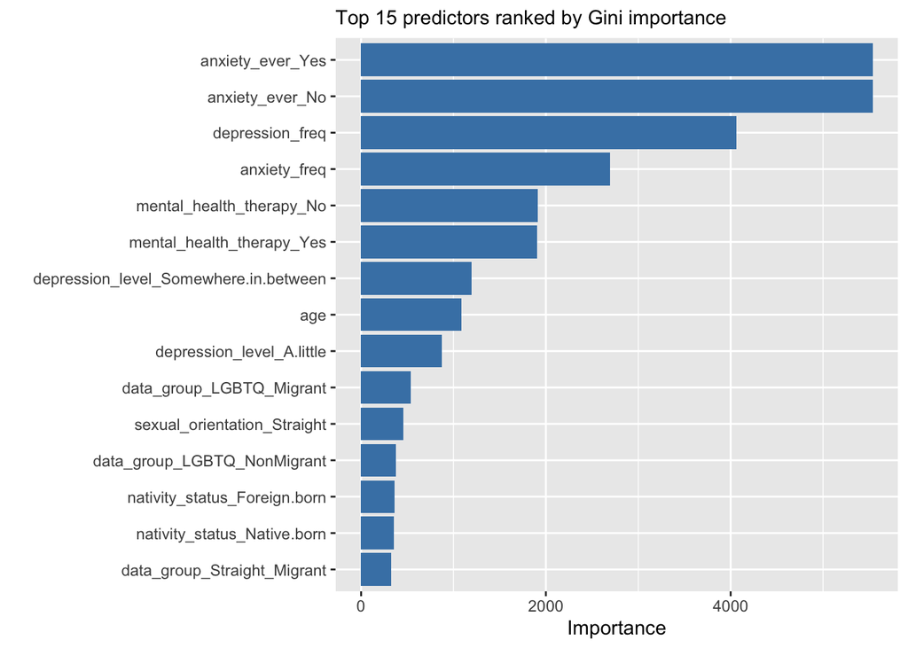

Figure 6: Variable importance plot for Decision Tree + Kitchen Sink model

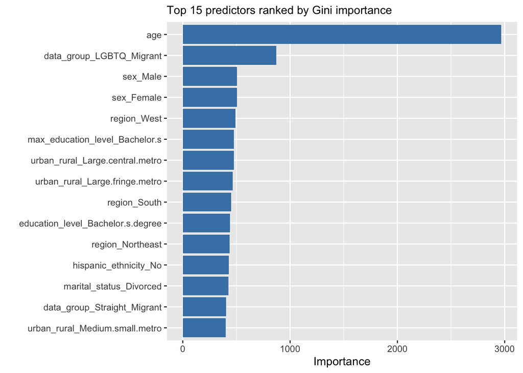

Figure 7: Variable importance plot for Decision Tree + M3 model

## SHAP Values

To further interpret how specific features influenced individual predictions, SHAP (SHapley Additive exPlanations) values were used to assess the contribution of individual features to model predictions. These plots decompose predictions into additive contributions from each input variable for a representative observation.

In the **Kitchen Sink model** (Figure Figure 8), the top SHAP contributors included:

- **Depression frequency and level**
- **Anxiety diagnosis (No)**
- **Sexual orientation and migrant status**
- **Lack of mental health therapy**

In the **M3 model** (Figure Figure 9), which excluded behavioral health indicators, a different set of patterns emerged. Major contributors included:

SHAP enhances model interpretability by clarifying not only which features are important, but also how they influence individual predictions.

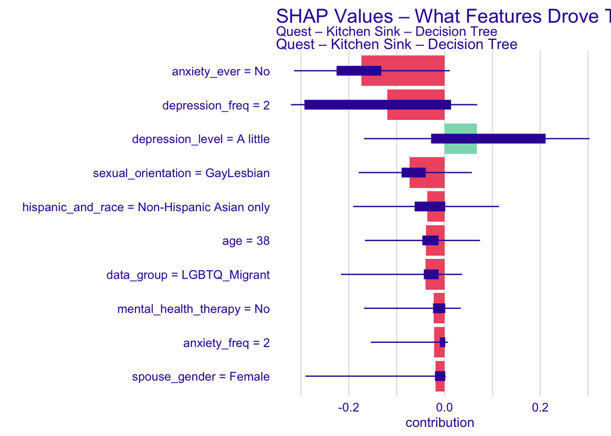

Figure 8: SHAP explanation for a prediction from the Kitchen Sink model

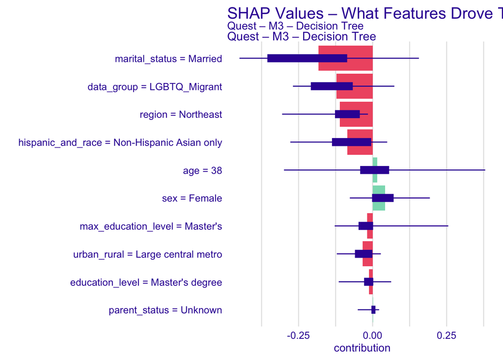

Figure 9: SHAP explanation for a prediction from the M3 model

## Partial Dependence Plots (PDPs)

Partial dependence plots (PDPs) were used to explore how individual features influence predicted depression risk, averaged across all individuals in the dataset.

In the **Kitchen Sink model** (Figure Figure 10), anxiety diagnosis stood out clearly:

- Respondents who had **ever been diagnosed with anxiety** were associated with a **substantially higher** predicted risk of depression.
- This aligns with well-established clinical relationships between anxiety and depression.

These PDPs reinforce earlier findings: **behavioral health variables** like anxiety diagnosis provide sharp predictive signals. When such variables are omitted, structural features like education fill the predictive gap, but result in weaker group-level separation.

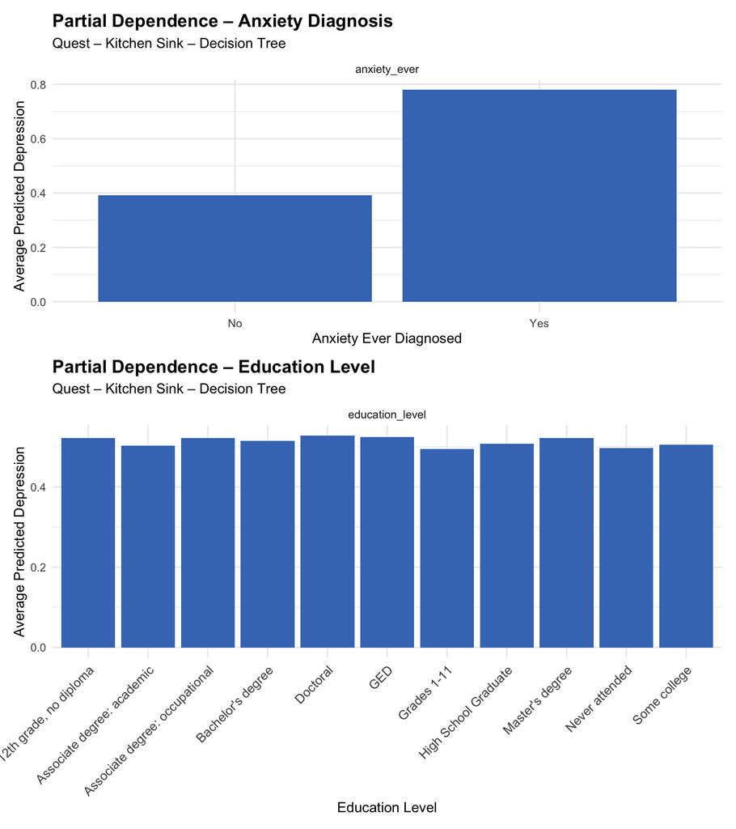

Figure 10: Partial Dependence – Kitchen Sink Model (Quest – Decision Tree)

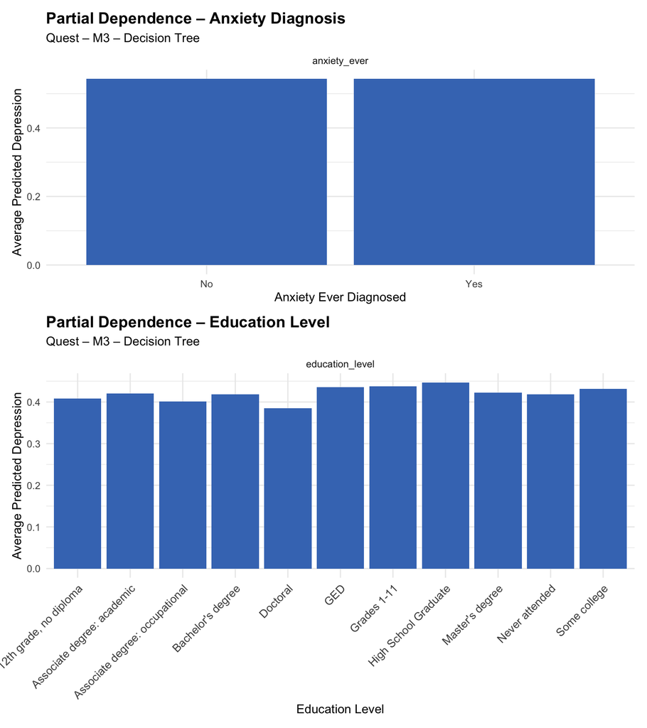

Figure 11: Partial Dependence – M3 Model (Quest – Decision Tree)

## Local Explanations

Local explanation plots were used to visualize how individual features contributed to specific predictions. These plots decompose the predicted probability for a single observation, showing how each feature shifted the prediction above or below the model’s baseline (0.5). Explanations were generated for both selected decision tree models: **Kitchen Sink** and **M3**, each trained and evaluated on Quest.

### Kitchen Sink Model

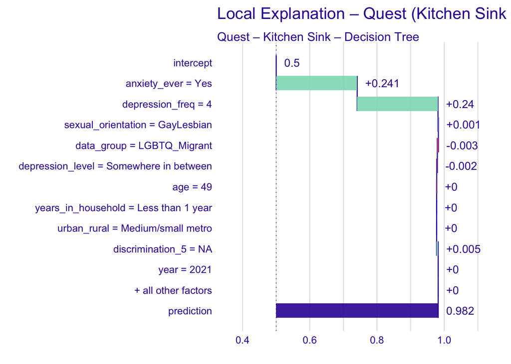

Figure 12: Local explanation for a single observation (Kitchen Sink model – Decision Tree)

Negative or neutral contributors included **age**, **region**, and **household tenure**. However, their magnitudes were minimal compared to the dominant behavioral health factors. This reinforces the earlier findings that when behavioral and access-to-care variables are available, they overwhelmingly shape model predictions.

### M3 Model

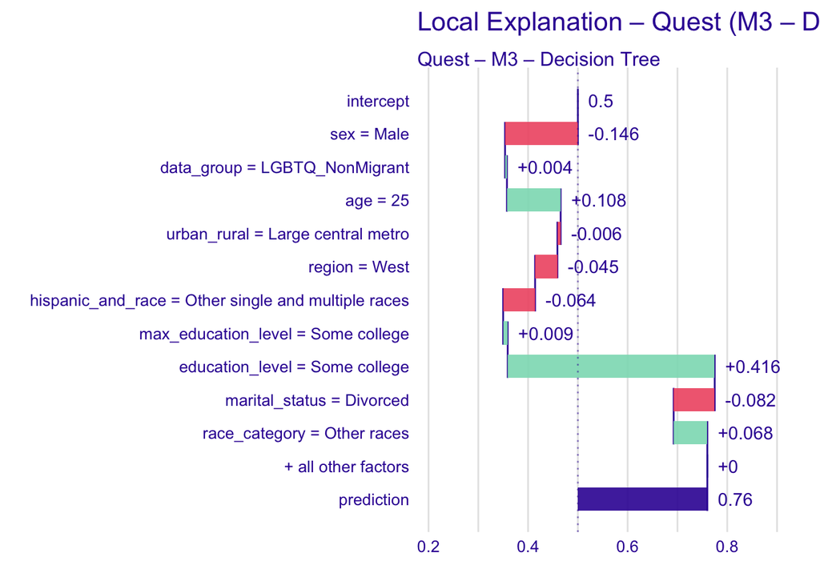

This breakdown illustrates how the model compensates for the absence of behavioral health data. Without information on anxiety or therapy use, the model shifts greater weight toward **demographic and social context**, still producing a relatively high-risk prediction, but based on a very different rationale and feature set.

# Discussion

Interpretability techniques—including SHAP values, partial dependence plots, and local explanations—deepened understanding of model behavior from both global and individual perspectives. These tools transformed the model from a black box into a transparent system, enabling clearer insight into the decision-making process—an especially valuable property in sociological and public health contexts where trust and accountability are essential.

While decision trees were selected due to their compatibility with interpretability tools, future work should explore the predictive potential of ensemble models like Random Forests or Boosted Trees. Although these are harder to interpret, they may yield improved raw performance. Running them as a benchmark would help clarify whether any significant predictive accuracy was traded off for the sake of explainability — and whether that tradeoff is justified in this context.

Ultimately, this work demonstrates how interpretable machine learning can serve as a bridge between computational rigor and sociological inquiry—supporting both predictive insight and structural reflection in public health research.

# Conclusion

This thesis set out to predict depression using interpretable machine learning models, with a particular focus on individuals situated at the intersection of structural disadvantage—namely, LGBTQ+ and migrant populations. Drawing on five years of National Health Interview Survey (NHIS) data, the project integrated sociological insight with algorithmic modeling to examine how demographic, medical, and social factors contribute to depression risk.

This project contributes to the growing body of work at the intersection of data science and social science by emphasizing transparency, subgroup fairness, and the integration of theory into applied modeling. Future work might explore additional model types, such as random forests or boosted trees, or extend this approach to other health outcomes and survey datasets. More broadly, this work offers a case study in using machine learning not only as a predictive tool, but also as a lens for reflecting on the structural forces that shape mental health across identity lines.

# Appendix

## Reproducibility & Data Access

This project involved modeling and data processing across two environments: a local machine and Northwestern’s Quest high-performance computing cluster. Due to file size and platform constraints, not all files — including code and outputs from Quest — could be hosted on GitHub.

Instead, a complete reproducibility folder has been created in Google Drive, which contains: - Full dataset files and modeling outputs - Quest-specific job scripts and results - Final rendered thesis files and figures

Google Drive folder: [Link](https://drive.google.com/drive/folders/1dKNWv3BAB8BY1Y5YK-MlU2HG12Ur1chd?usp=sharing)

Code for preprocessing and local experimentation is available on GitHub:  
[Link to Repository](https://github.com/ali3el/alis-thesis.git)

To fully reproduce the results, download the Drive folder, follow the directory structure described in the included README, and refer to the GitHub repo for project context and code dependencies.